# Lab 4: Boosting

## Import, Wrangle, and Clean Dataset

```python
import pandas as pd
import numpy as np

# import and use pandas to read and store the dataset
df = pd.read_csv("heart_2020_cleaned.csv")
```

Taking a look at the dataset, it contains both categorical and numeric data. Categorical data includes: **HeartDisease, Smoking, AlcoholDrinking, Stroke, DiffWalking, Sex, AgeCategory, Race, Diabetic, PhysicalActivity, GenHealth, Asthma, KidneyDisease, and SkinCancer**. Numeric data includes: **BMI, PhysicalHealth, MentalHealth, and SleepTime**. Later we will use LabelEncoder to transform the categorical data so it can be easily read by the machine learning models in Python.

```python
# display the dataset
display(df)
```

|  | HeartDisease | BMI | Smoking | AlcoholDrinking | Stroke | PhysicalHealth | MentalHealth | DiffWalking | Sex | AgeCategory | Race | Diabetic | PhysicalActivity | GenHealth | SleepTime | Asthma | KidneyDisease | SkinCancer |
| --- | --- | --- | --- | --- | --- | --- | --- | --- | --- | --- | --- | --- | --- | --- | --- | --- | --- | --- |
| 0 | No | 16.60 | Yes | No | No | 3.0 | 30.0 | No | Female | 55-59 | White | Yes | Yes | Very good | 5.0 | Yes | No | Yes |
| 1 | No | 20.34 | No | No | Yes | 0.0 | 0.0 | No | Female | 80 or older | White | No | Yes | Very good | 7.0 | No | No | No |
| 2 | No | 26.58 | Yes | No | No | 20.0 | 30.0 | No | Male | 65-69 | White | Yes | Yes | Fair | 8.0 | Yes | No | No |
| 3 | No | 24.21 | No | No | No | 0.0 | 0.0 | No | Female | 75-79 | White | No | No | Good | 6.0 | No | No | Yes |
| 4 | No | 23.71 | No | No | No | 28.0 | 0.0 | Yes | Female | 40-44 | White | No | Yes | Very good | 8.0 | No | No | No |
| ... | ... | ... | ... | ... | ... | ... | ... | ... | ... | ... | ... | ... | ... | ... | ... | ... | ... | ... |
| 319790 | Yes | 27.41 | Yes | No | No | 7.0 | 0.0 | Yes | Male | 60-64 | Hispanic | Yes | No | Fair | 6.0 | Yes | No | No |
| 319791 | No | 29.84 | Yes | No | No | 0.0 | 0.0 | No | Male | 35-39 | Hispanic | No | Yes | Very good | 5.0 | Yes | No | No |
| 319792 | No | 24.24 | No | No | No | 0.0 | 0.0 | No | Female | 45-49 | Hispanic | No | Yes | Good | 6.0 | No | No | No |
| 319793 | No | 32.81 | No | No | No | 0.0 | 0.0 | No | Female | 25-29 | Hispanic | No | No | Good | 12.0 | No | No | No |
| 319794 | No | 46.56 | No | No | No | 0.0 | 0.0 | No | Female | 80 or older | Hispanic | No | Yes | Good | 8.0 | No | No | No |

319795 rows × 18 columns

## Exploratory Analysis and Visualizations

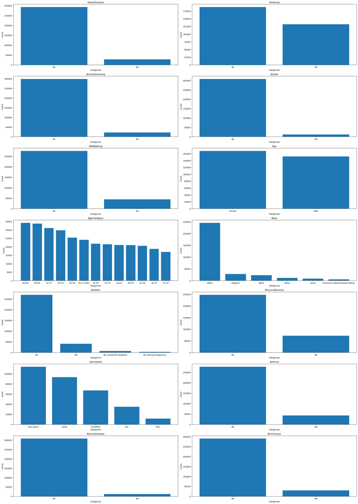

```python
import matplotlib.pyplot as plt

# create a new dataframe with only the categorical variables from the original dataset
categorical_data = df.select_dtypes(include=[object])

# make a grid for the graphs to be placed in
fig, axes = plt.subplots(nrows=7, ncols=2, figsize=(25,35))
axes = axes.flatten()

# for loop takes each column in the dataset, counts values, and plots a graph
for i, col in enumerate(categorical_data.columns):
    category_counts = df[col].value_counts()

    axes[i].bar(category_counts.index, category_counts.values)
    axes[i].set_title(col)
    axes[i].set_xlabel('Categories')
    axes[i].set_ylabel('Count')

plt.tight_layout()
plt.show()
```

```python
#summary statistic of all numeric data
df.describe()
```

|  | BMI | PhysicalHealth | MentalHealth | SleepTime |
| --- | --- | --- | --- | --- |
| count | 319795.000000 | 319795.00000 | 319795.000000 | 319795.000000 |
| mean | 28.325399 | 3.37171 | 3.898366 | 7.097075 |
| std | 6.356100 | 7.95085 | 7.955235 | 1.436007 |
| min | 12.020000 | 0.00000 | 0.000000 | 1.000000 |
| 25% | 24.030000 | 0.00000 | 0.000000 | 6.000000 |
| 50% | 27.340000 | 0.00000 | 0.000000 | 7.000000 |
| 75% | 31.420000 | 2.00000 | 3.000000 | 8.000000 |
| max | 94.850000 | 30.00000 | 30.000000 | 24.000000 |

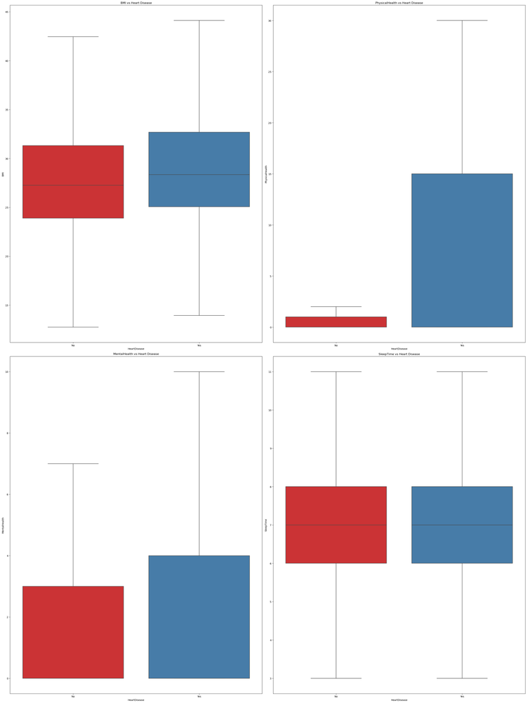

```python
import seaborn as sns
# create a new dataframe with only the numeric variables from the original dataset
numeric_data = df.select_dtypes(include=[np.number])

# make a grid for the graphs to be placed in
fig, axes = plt.subplots(nrows=2, ncols=2, figsize=(30,40))
axes = axes.flatten()

# for loop takes each column in the dataset, creates a boxplot, and plots a graph
for i, col in enumerate(numeric_data.columns):

    ax = sns.boxplot(x=df["HeartDisease"], y=col, data=df, ax=axes[i], palette='Set1', showfliers=False)
    ax.set_xlabel("HeartDisease")
    ax.set_ylabel(col)
    axes[i].set_title(col + " vs Heart Disease")

plt.tight_layout()
plt.show()
```

## More Data Wrangling

The function LabelEncoder is used to transform the categorical values so the Python can easily run machine learning models. For example, Smoking[Yes, No] transform into Smoking[1, 0] where "Yes" = 1 and "No" = 0.

```python
from sklearn.preprocessing import LabelEncoder

# go through the dataset and if a column is categorical, transform the variables using LabelEncoder
df["HeartDisease"] = LabelEncoder().fit(df['HeartDisease']).transform(df['HeartDisease'])
df["Smoking"] = LabelEncoder().fit(df['Smoking']).transform(df['Smoking'])
df["AlcoholDrinking"] = LabelEncoder().fit(df['AlcoholDrinking']).transform(df['AlcoholDrinking'])
df["Stroke"] = LabelEncoder().fit(df['Stroke']).transform(df['Stroke'])
df["DiffWalking"] = LabelEncoder().fit(df['DiffWalking']).transform(df['DiffWalking'])
df["Sex"] = LabelEncoder().fit(df['Sex']).transform(df['Sex'])
df["AgeCategory"] = LabelEncoder().fit(df['AgeCategory']).transform(df['AgeCategory'])
df["Race"] = LabelEncoder().fit(df['Race']).transform(df['Race'])
df["Diabetic"] = LabelEncoder().fit(df['Diabetic']).transform(df['Diabetic'])
df["PhysicalActivity"] = LabelEncoder().fit(df['PhysicalActivity']).transform(df['PhysicalActivity'])
df["GenHealth"] = LabelEncoder().fit(df['GenHealth']).transform(df['GenHealth'])
df["Asthma"] = LabelEncoder().fit(df['Asthma']).transform(df['Asthma'])
df["KidneyDisease"] = LabelEncoder().fit(df['KidneyDisease']).transform(df['KidneyDisease'])
df["SkinCancer"] = LabelEncoder().fit(df['SkinCancer']).transform(df['SkinCancer'])

# display the new dataset
display(df)
```

|  | HeartDisease | BMI | Smoking | AlcoholDrinking | Stroke | PhysicalHealth | MentalHealth | DiffWalking | Sex | AgeCategory | Race | Diabetic | PhysicalActivity | GenHealth | SleepTime | Asthma | KidneyDisease | SkinCancer |
| --- | --- | --- | --- | --- | --- | --- | --- | --- | --- | --- | --- | --- | --- | --- | --- | --- | --- | --- |
| 0 | 0 | 16.60 | 1 | 0 | 0 | 3.0 | 30.0 | 0 | 0 | 7 | 5 | 2 | 1 | 4 | 5.0 | 1 | 0 | 1 |
| 1 | 0 | 20.34 | 0 | 0 | 1 | 0.0 | 0.0 | 0 | 0 | 12 | 5 | 0 | 1 | 4 | 7.0 | 0 | 0 | 0 |
| 2 | 0 | 26.58 | 1 | 0 | 0 | 20.0 | 30.0 | 0 | 1 | 9 | 5 | 2 | 1 | 1 | 8.0 | 1 | 0 | 0 |
| 3 | 0 | 24.21 | 0 | 0 | 0 | 0.0 | 0.0 | 0 | 0 | 11 | 5 | 0 | 0 | 2 | 6.0 | 0 | 0 | 1 |
| 4 | 0 | 23.71 | 0 | 0 | 0 | 28.0 | 0.0 | 1 | 0 | 4 | 5 | 0 | 1 | 4 | 8.0 | 0 | 0 | 0 |
| ... | ... | ... | ... | ... | ... | ... | ... | ... | ... | ... | ... | ... | ... | ... | ... | ... | ... | ... |
| 319790 | 1 | 27.41 | 1 | 0 | 0 | 7.0 | 0.0 | 1 | 1 | 8 | 3 | 2 | 0 | 1 | 6.0 | 1 | 0 | 0 |
| 319791 | 0 | 29.84 | 1 | 0 | 0 | 0.0 | 0.0 | 0 | 1 | 3 | 3 | 0 | 1 | 4 | 5.0 | 1 | 0 | 0 |
| 319792 | 0 | 24.24 | 0 | 0 | 0 | 0.0 | 0.0 | 0 | 0 | 5 | 3 | 0 | 1 | 2 | 6.0 | 0 | 0 | 0 |
| 319793 | 0 | 32.81 | 0 | 0 | 0 | 0.0 | 0.0 | 0 | 0 | 1 | 3 | 0 | 0 | 2 | 12.0 | 0 | 0 | 0 |
| 319794 | 0 | 46.56 | 0 | 0 | 0 | 0.0 | 0.0 | 0 | 0 | 12 | 3 | 0 | 1 | 2 | 8.0 | 0 | 0 | 0 |

319795 rows × 18 columns

Now split the clean and encoded dataset into Training and Testing sets. Splitting the dataset is important to estimate the performance of machine learning models and prevent overfitting or prevent the model on not performing well on unseen data. The most common split is 20% for testing and 80% for training the model.

```python
from sklearn.model_selection import train_test_split

# create train and test set with 80% training and 20% testing
train_df, test_df = train_test_split(df, train_size=0.80)

# split independent and dependent variables for training
X_train= train_df.drop('HeartDisease', axis=1)
y_train= train_df['HeartDisease']

# split independent and dependent variables for testing
X_test= test_df.drop('HeartDisease', axis=1)
y_test= test_df['HeartDisease']
```

Here, we have an issue of imbalance training data for the dependent variable. This can cause issues in model performance and interpretation. Imbalanced data can:

```
- lead to the accuracy score being better than what it really is, inaccurate performace results
- be biased towards the majority class only
- lead to overfitting
```

To solve this issue, SMOTE is used. SMOTE is a oversampling technique. Here the sample size of the Minority class is increased to match it with the sample size of Majority Class. In this example, "Yes" or 1 is the Minority class and "No" or 0 is the Majority class.

After oversampling, the new training set called y_SMOTE and has the same numbers of Yes and No!

Last, we standardize and normalize all the independent values for better model performance.

```python
y_train.value_counts()
```

```
0    233973
1     21863
Name: HeartDisease, dtype: int64
```

```python
from imblearn.over_sampling import SMOTE

smote = SMOTE(sampling_strategy='minority')
X_train_smote , y_train_smote = smote.fit_resample(X_train,y_train)

y_train_smote.value_counts()
```

```
1    233973
0    233973
Name: HeartDisease, dtype: int64
```

```python
from sklearn.preprocessing import StandardScaler

# standardize and normalize values
sc=StandardScaler()
X_train_smote=sc.fit_transform(X_train_smote)
X_test=sc.transform(X_test)
```

## Machine Learning Models

**Can you indicate which variables have a significant effect on the likelihood of heart disease?**

Compared to all the models tested (Logistic Regression, Random Forest, AdaBoost, and XGBoost), the Random Forest model performed the best. It had the highest accuracy, highest true negative, lowest false positve, but the highest false negative. But overall, it performs the best compared to the other models.

```python
import statsmodels.api as sm

# using all values to see which variables are significant
X = df.drop(columns = ["HeartDisease"])
y = df['HeartDisease']

# fit the Logistic model
results = sm.OLS(y, X).fit()

# print the stats
print(results.summary())
```

```
                                 OLS Regression Results
=======================================================================================
Dep. Variable:           HeartDisease   R-squared (uncentered):                   0.205
Model:                            OLS   Adj. R-squared (uncentered):              0.205
Method:                 Least Squares   F-statistic:                              4842.
Date:                                   Prob (F-statistic):                        0.00
Time:                        01:33:46   Log-Likelihood:                         -24094.
No. Observations:              319795   AIC:                                  4.822e+04
Df Residuals:                  319778   BIC:                                  4.840e+04
Df Model:                          17
Covariance Type:            nonrobust
====================================================================================
                       coef    std err          t      P>|t|      [0.025      0.975]
------------------------------------------------------------------------------------
BMI                 -0.0008    6.2e-05    -12.126      0.000      -0.001      -0.001
Smoking              0.0248      0.001     25.622      0.000       0.023       0.027
AlcoholDrinking     -0.0182      0.002     -9.835      0.000      -0.022      -0.015
Stroke               0.1923      0.002     77.320      0.000       0.187       0.197
PhysicalHealth       0.0023   6.74e-05     34.348      0.000       0.002       0.002
MentalHealth         0.0003   6.25e-05      5.268      0.000       0.000       0.000
DiffWalking          0.0585      0.002     37.014      0.000       0.055       0.062
Sex                  0.0486      0.001     51.860      0.000       0.047       0.050
AgeCategory          0.0120      0.000     81.811      0.000       0.012       0.012
Race                -0.0005      0.000     -1.358      0.174      -0.001       0.000
Diabetic             0.0327      0.001     47.798      0.000       0.031       0.034
PhysicalActivity    -0.0164      0.001    -14.581      0.000      -0.019      -0.014
GenHealth           -0.0025      0.000     -8.469      0.000      -0.003      -0.002
SleepTime           -0.0036      0.000    -13.876      0.000      -0.004      -0.003
Asthma               0.0205      0.001     14.876      0.000       0.018       0.023
KidneyDisease        0.1126      0.003     44.776      0.000       0.108       0.118
SkinCancer           0.0279      0.002     16.899      0.000       0.025       0.031
==============================================================================
Omnibus:                   155255.197   Durbin-Watson:                   1.995
Prob(Omnibus):                  0.000   Jarque-Bera (JB):           737731.468
Skew:                           2.440   Prob(JB):                         0.00
Kurtosis:                       8.616   Cond. No.                         174.
==============================================================================

Notes:
[1] R² is computed without centering (uncentered) since the model does not contain a constant.
[2] Standard Errors assume that the covariance matrix of the errors is correctly specified.
```

```python
from sklearn.linear_model import LogisticRegression
from sklearn.metrics import accuracy_score

# fit on training and predict on testing dataset
model = LogisticRegression()
model.fit(X_train_smote, y_train_smote)
y_pred = model.predict(X_test)

# get the accuracy score
score = accuracy_score(y_test, y_pred)
print('Accuracy = %.2f' % (score*100) + '%')
```

```
Accuracy = 70.32%
```

The Logistic Regression Model has a very high false postive

```
<sklearn.metrics._plot.confusion_matrix.ConfusionMatrixDisplay at 0x7fdbe542a7c0>
```

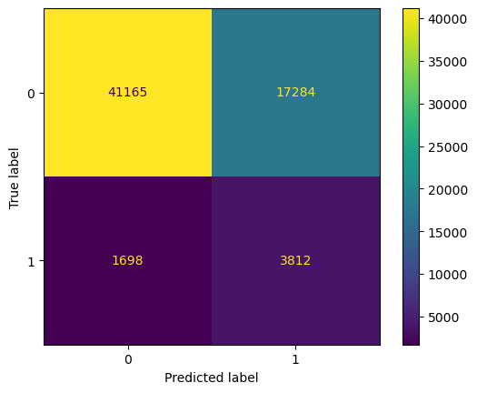

```python
from sklearn.metrics import confusion_matrix, ConfusionMatrixDisplay

# create and plot confusion matrix
cm = confusion_matrix(y_test, y_pred)
ConfusionMatrixDisplay(cm).plot()
```

```python
from sklearn.ensemble import RandomForestClassifier

# fit on training and predict on testing dataset
model = RandomForestClassifier()
model.fit(X_train_smote, y_train_smote)
y_pred = model.predict(X_test)

# get the accuracy score
score = accuracy_score(y_test, y_pred)
print('Accuracy = %.2f' % (score*100) + '%')
```

```
Accuracy = 85.35%
```

The Random Forest Model performs very well. The True Positive is a bit low compared to the other models.

```
<sklearn.metrics._plot.confusion_matrix.ConfusionMatrixDisplay at 0x7fdb70525550>
```

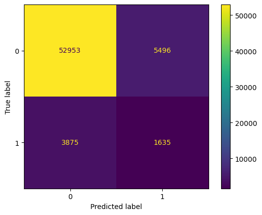

```python
# create and plot confusion matrix
cm = confusion_matrix(y_test, y_pred)
ConfusionMatrixDisplay(cm).plot()
```

```python
from sklearn.ensemble import AdaBoostClassifier

# fit on training and predict on testing dataset
model = AdaBoostClassifier()
model.fit(X_train_smote, y_train_smote)
y_pred = model.predict(X_test)

# get the accuracy score
score = accuracy_score(y_test, y_pred)
print('Accuracy = %.2f' % (score*100) + '%')
```

```
Accuracy = 76.13%
```

```
<sklearn.metrics._plot.confusion_matrix.ConfusionMatrixDisplay at 0x7fdbe6df6100>
```

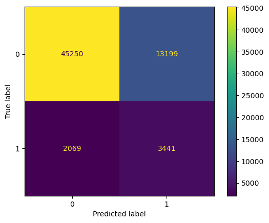

```python
# create and plot confusion matrix
cm = confusion_matrix(y_test, y_pred)
ConfusionMatrixDisplay(cm).plot()
```

```python
from xgboost import XGBClassifier

# fit on training and predict on testing dataset
model = XGBClassifier()
model.fit(X_train_smote, y_train_smote)
y_pred = model.predict(X_test)

# get the accuracy score
score = accuracy_score(y_test, y_pred)
print('Accuracy = %.2f' % (score*100) + '%')
```

```
Accuracy = 83.83%
```

The XGBoost Model has a lower False Positive compared to the Logistic and AdaBoost Model, but does not perform as well as the Random Forest Model.

```
<sklearn.metrics._plot.confusion_matrix.ConfusionMatrixDisplay at 0x7fdbe6df64f0>
```

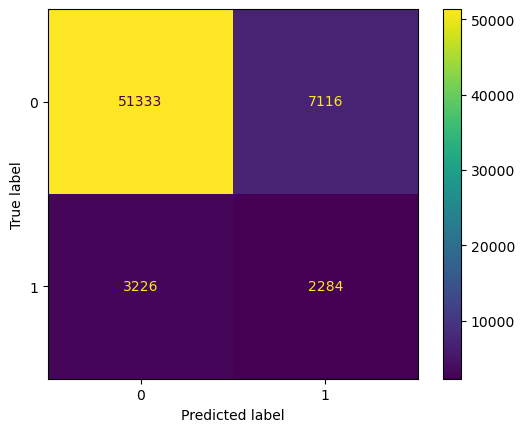

```python
# create and plot confusion matrix
cm = confusion_matrix(y_test, y_pred)
ConfusionMatrixDisplay(cm).plot()
```